# Project Pima Diabetes_Automatic Learning

## Missing Values:

```r
length(PimaIndiansDiabetes$insulin[which(PimaIndiansDiabetes$insulin==0)])
```

```
## [1] 374
```

From common sense, we know Insulin must have something to do with Diabetes, so even we have 374 out of 768 missing Insulin data, we cannot delete Insulin variable. For data accuracy, we could not compute missing value as mean of total neither. So we decide to delete all missing value rows.

```r
cor(as.numeric(PimaIndiansDiabetes$diabetes),PimaIndiansDiabetes$insulin)
```

```
## [1] 0.130548
```

```r
PimaIndiansDiabetes<-PimaIndiansDiabetes[!as.logical(rowSums(PimaIndiansDiabetes[,2:8]==0)), ]
cor(as.numeric(PimaIndiansDiabetes$diabetes),PimaIndiansDiabetes$insulin)
```

```
## [1] 0.3014292
```

We can see significant increase in correlation between Insluin and Diabetes.

## Bagging

```r
library(randomForest)
library(ISLR)
rawdata<-PimaIndiansDiabetes
attach(rawdata)
B <- 5000
n <- nrow(rawdata);  p <- ncol(rawdata)-1    # No. of observations (n) and predictors (p).

set.seed(1)
train <- sample(n,0.8*n+1)

rawdata.test <- subset(rawdata[-train,], select=-diabetes)
diabetes.test <- rawdata$diabetes[-train]

set.seed(1)
bag.model <- randomForest(as.factor(diabetes) ~ ., data=rawdata,
                         subset=train,
                         xtest = rawdata.test, ytest =as.factor(diabetes.test),
                         ntree=B,
                         mtry=p,
                         importance=T)
bag.model
```

```
##
## Call:
##  randomForest(formula = as.factor(diabetes) ~ ., data = rawdata,      xtest = rawdata.test, ytest = as.factor(diabetes.test), ntree = B,      mtry = p, importance = T, subset = train)
##                Type of random forest: classification
##                      Number of trees: 5000
## No. of variables tried at each split: 8
##
##         OOB estimate of  error rate: 22.29%
## Confusion matrix:
##     0  1 class.error
## 0 190 24   0.1121495
## 1  46 54   0.4600000
##                 Test set error rate: 25.64%
## Confusion matrix:
##    0  1 class.error
## 0 44  4  0.08333333
## 1 16 14  0.53333333
```

## Random Foreast

```r
library(randomForest)
library(ISLR)
rawdata<-PimaIndiansDiabetes
attach(rawdata)
B <- 5000
n <- nrow(rawdata);  p <- ncol(rawdata)-1    # No. of observations (n) and predictors (p).

set.seed(1)
train <- sample(n,0.8*n+1)

rawdata.test <- subset(rawdata[-train,], select=-diabetes)
diabetes.test <- rawdata$diabetes[-train]

set.seed(1)
rf.model <- randomForest(as.factor(diabetes) ~ ., data=rawdata,
                         subset=train,
                         xtest = rawdata.test, ytest =as.factor(diabetes.test),
                         ntree=B,
                         mtry=sqrt(p),
                         importance=T)
rf.model
```

```
##
## Call:
##  randomForest(formula = as.factor(diabetes) ~ ., data = rawdata,      xtest = rawdata.test, ytest = as.factor(diabetes.test), ntree = B,      mtry = sqrt(p), importance = T, subset = train)
##                Type of random forest: classification
##                      Number of trees: 5000
## No. of variables tried at each split: 3
##
##         OOB estimate of  error rate: 22.29%
## Confusion matrix:
##     0  1 class.error
## 0 188 26   0.1214953
## 1  44 56   0.4400000
##                 Test set error rate: 23.08%
## Confusion matrix:
##    0  1 class.error
## 0 44  4  0.08333333
## 1 14 16  0.46666667
```

Random Forest Test set error rate is 23.08%, among 30 true diabetes, only 16 got tested, detect rate is 1-0.467=0.533. Notice 23.08% is lower than 25.64% for bagging tree. But not such a difference. And for OOB they are pretty much same.

```r
subset(rawdata[-train,])[-which(rf.model$test$predicted==diabetes.test),] # wrong predicted results
```

```
##     pregnant glucose pressure triceps insulin mass pedigree age diabetes
## 7          3      78       50      32      88 31.0    0.248  26        1
## 55         7     150       66      42     342 34.7    0.718  42        0
## 126        1      88       30      42      99 55.0    0.496  26        1
## 151        1     136       74      50     204 37.4    0.399  24        0
## 166        6     104       74      18     156 29.9    0.722  41        1
## 189        8     109       76      39     114 27.9    0.640  31        1
## 190        5     139       80      35     160 31.6    0.361  25        1
## 199        4     109       64      44      99 34.8    0.905  26        1
## 244        6     119       50      22     176 27.1    1.318  33        1
## 297        2     146       70      38     360 28.0    0.337  29        1
## 299       14     100       78      25     184 36.6    0.412  46        1
## 403        5     136       84      41      88 35.0    0.286  35        1
## 429        0     135       94      46     145 40.6    0.284  26        0
## 430        1      95       82      25     180 35.0    0.233  43        1
## 494        4     125       70      18     122 28.9    1.144  45        1
## 516        3     163       70      18     105 31.6    0.268  28        1
## 585        8     124       76      24     600 28.7    0.687  52        1
## 595        6     123       72      45     230 33.6    0.733  34        0
```

## Improve RF performance

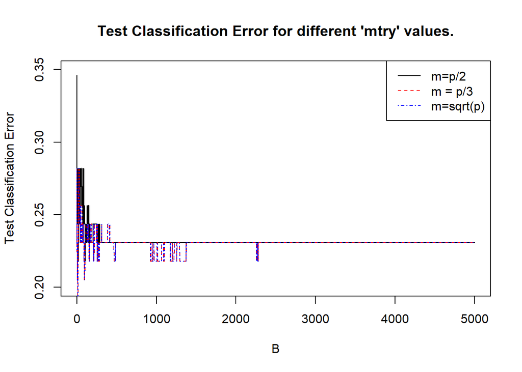

```r
set.seed(1)
all.err <- NULL
for (mtry in c(p/2,p/3,sqrt(p))){
  set.seed(1)
  rf.model <- randomForest(as.factor(diabetes) ~ ., data=rawdata,
                           subset=train,
                           xtest = rawdata.test, ytest =as.factor(diabetes.test),
                           ntree=5000,
                           mtry=mtry,
                           importance=T)
  all.err <- cbind(all.err, rf.model$test$err.rate[,1])
}
# Plot the test error rate progressions for baggin and two random forest versions.
matplot(all.err, type="l", ylim=c(0.2,0.35),
        ylab="Test Classification Error", xlab="B",
        main="Test Classification Error for different 'mtry' values.",
        col=c(1,2,4))

legend("topright",
       lty=c(1,2,4),
       col=c(1,2,4),
       legend=c("m=p/2","m = p/3",
                "m=sqrt(p)"))
```

As we can see, doesn’t matter how we set mtry, they all converge to 23.08%

# Tune Mtry

```r
library(caret)
# Create model with default paramters
control <- trainControl(method="repeatedcv", number=10, repeats=3)
metric <- "Accuracy"
set.seed(1)
mtry <- sqrt(p)
tunegrid <- expand.grid(.mtry=mtry)
rf_default <- train(as.factor(diabetes)~., data=rawdata, method="rf", metric=metric, tuneGrid=tunegrid, trControl=control)
print(rf_default)
```

```
## Random Forest
##
## 392 samples
##   8 predictor
##   2 classes: '0', '1'
##
## No pre-processing
## Resampling: Cross-Validated (10 fold, repeated 3 times)
## Summary of sample sizes: 353, 353, 353, 352, 353, 353, ...
## Resampling results:
##
##   Accuracy   Kappa
##   0.7858974  0.5000359
##
## Tuning parameter 'mtry' was held constant at a value of 2.828427
```

```r
# sqrt(p)
  # Accuracy   Kappa
  # 0.7858974  0.5000359
# Random Search
control <- trainControl(method="repeatedcv", number=10, repeats=3, search="random")
set.seed(1)
mtry <- sqrt(p)
rf_random <- train(as.factor(diabetes)~., data=rawdata, method="rf", metric=metric, tuneLength=15, trControl=control)
print(rf_random)
```

```
## Random Forest
##
## 392 samples
##   8 predictor
##   2 classes: '0', '1'
##
## No pre-processing
## Resampling: Cross-Validated (10 fold, repeated 3 times)
## Summary of sample sizes: 353, 353, 353, 352, 353, 353, ...
## Resampling results across tuning parameters:
##
##   mtry  Accuracy   Kappa
##   1     0.7740171  0.4646896
##   2     0.7824786  0.4907644
##   3     0.7875855  0.5038099
##   4     0.7858761  0.5000548
##   5     0.7858761  0.5012933
##   6     0.7850855  0.4986744
##   7     0.7774359  0.4790418
##   8     0.7782692  0.4875309
##
## Accuracy was used to select the optimal model using the largest value.
## The final value used for the model was mtry = 3.
```

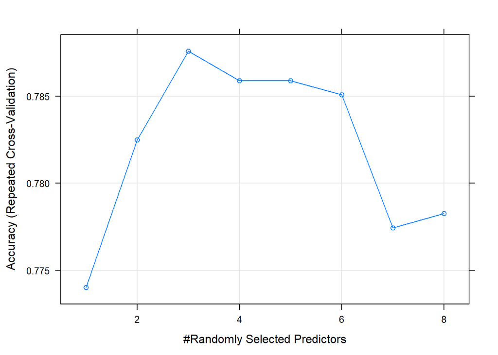

```r
plot(rf_random)
```

```r
  # mtry  Accuracy   Kappa
  # 1     0.7740171  0.4646896
  # 2     0.7824786  0.4907644
  # 3     0.7875855  0.5038099 #Best mtry
  # 4     0.7858761  0.5000548
  # 5     0.7858761  0.5012933
  # 6     0.7850855  0.4986744
  # 7     0.7774359  0.4790418
  # 8     0.7782692  0.4875309
# Grid Search
control <- trainControl(method="repeatedcv", number=10, repeats=3, search="grid")
set.seed(1)
tunegrid <- expand.grid(.mtry=c(1:p))
rf_gridsearch <- train(as.factor(diabetes)~., data=rawdata, method="rf", metric=metric, tuneGrid=tunegrid, trControl=control)
print(rf_gridsearch)
```

```
## Random Forest
##
## 392 samples
##   8 predictor
##   2 classes: '0', '1'
##
## No pre-processing
## Resampling: Cross-Validated (10 fold, repeated 3 times)
## Summary of sample sizes: 353, 353, 353, 352, 353, 353, ...
## Resampling results across tuning parameters:
##
##   mtry  Accuracy   Kappa
##   1     0.7773932  0.4670298
##   2     0.7841453  0.4941200
##   3     0.7884402  0.5059865
##   4     0.7867521  0.5035276
##   5     0.7808120  0.4883607
##   6     0.7774145  0.4784565
##   7     0.7765812  0.4778307
##   8     0.7757051  0.4760643
##
## Accuracy was used to select the optimal model using the largest value.
## The final value used for the model was mtry = 3.
```

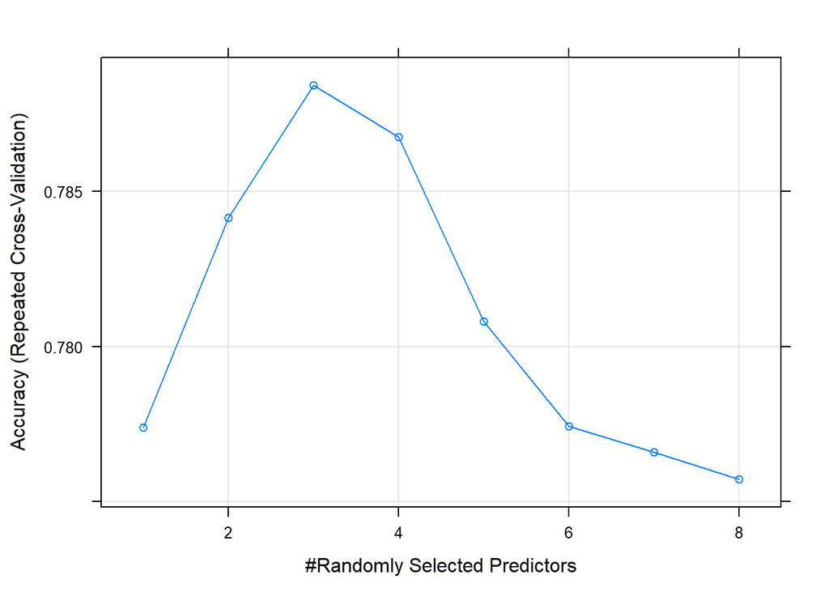

```r
plot(rf_gridsearch)
```

```r
  # mtry  Accuracy   Kappa
  # 1     0.7773932  0.4670298
  # 2     0.7841453  0.4941200
  # 3     0.7884402  0.5059865 #Best mtry
  # 4     0.7867521  0.5035276
  # 5     0.7808120  0.4883607
  # 6     0.7774145  0.4784565
  # 7     0.7765812  0.4778307
  # 8     0.7757051  0.4760643
```

Stick with sqrt(p), as sqrt(p=8)=2.83~3

## Variable importance

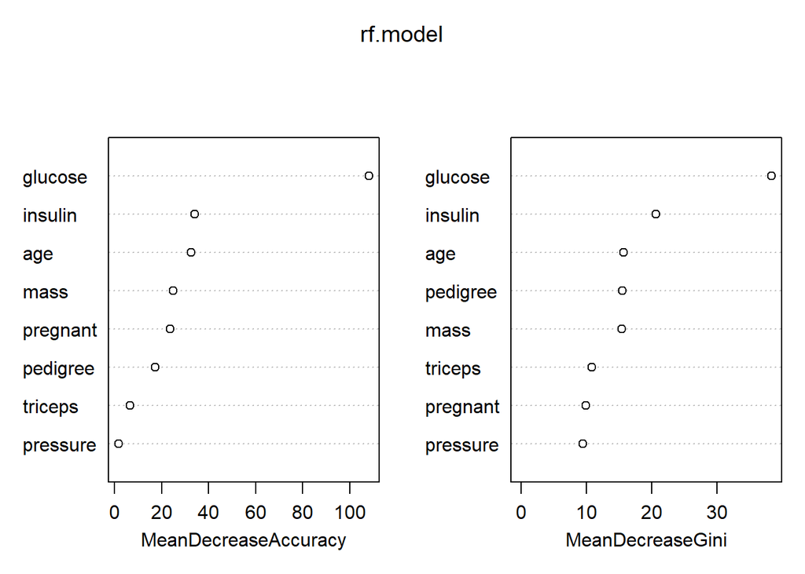

```r
varImpPlot(rf.model)
```

As it’s classification question, we use Gini for final results. Variable importance rank as Top 3 Glucose, Insulin, Age. But notice Age, Pedigree, Mass they are very close. To further analyst variable, we take a step back to correlation matrix.

## Variable Correlation:

```r
# flattenCorrMatrix, make matrix to column cor(a,b)
# cormat : matrix of the correlation coefficients
# pmat : matrix of the correlation p-values
flattenCorrMatrix <- function(cormat, pmat) {
  ut <- upper.tri(cormat)
  data.frame(
    row = rownames(cormat)[row(cormat)[ut]],
    column = rownames(cormat)[col(cormat)[ut]],
    cor  =(cormat)[ut],
    p = pmat[ut]
    )
}
library(Hmisc)
res<-cor(PimaIndiansDiabetes)
res2<-rcorr(as.matrix(PimaIndiansDiabetes[,1:9]))
corfla<-flattenCorrMatrix(res2$r, res2$P)
```

visualize the correlation matrix

```r
corfla[which.max(abs(corfla$cor)),] #max abs(cor)=0.6796
```

```
##         row column       cor p
## 22 pregnant    age 0.6796085 0
```

```r
corfla[which.min(abs(corfla$cor)),] #min abs(cor)=0.0076
```

```
##         row   column         cor         p
## 16 pregnant pedigree 0.007562116 0.8813593
```

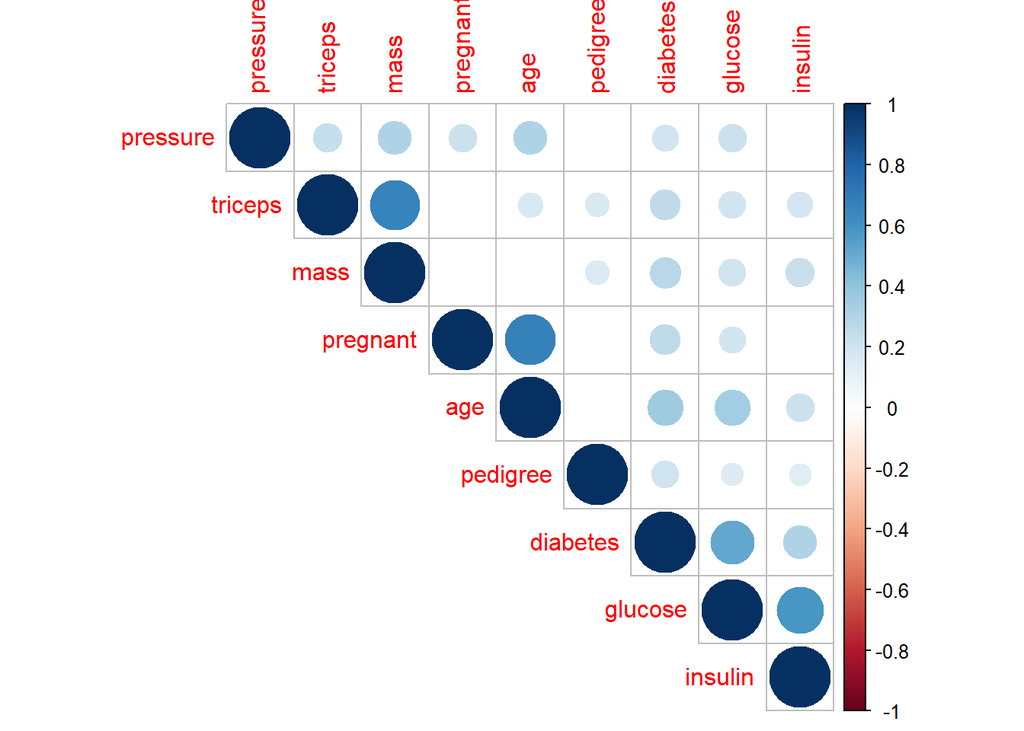

```r
#plot corrlation matrix
#install.packages("corrplot")
library(corrplot)
# corrplot(res, type = "upper", order = "hclust",
#          tl.col = "black", tl.srt = 45)
# Insignificant correlations are leaved blank
corrplot(res2$r, type="upper", order="hclust",
         p.mat = res2$P, sig.level = 0.01, insig = "blank")
```

```r
# correlation paris and number
library("PerformanceAnalytics")
```

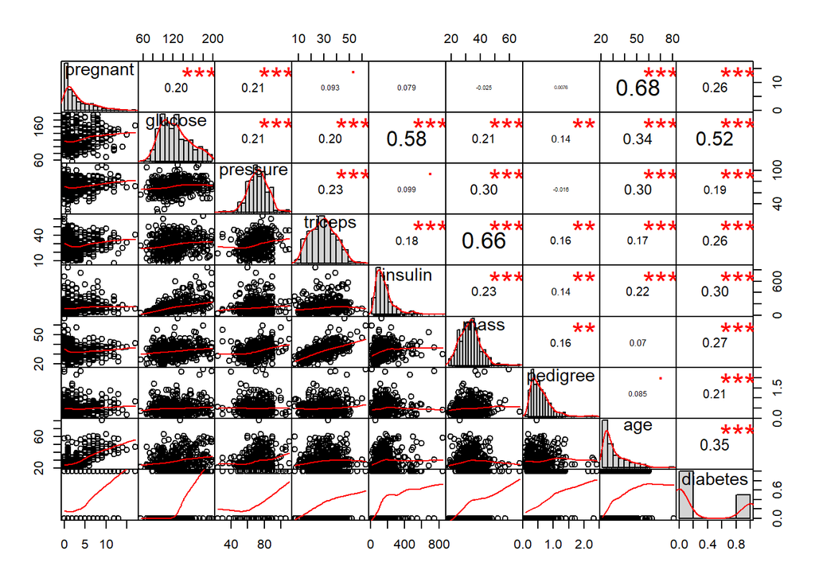

```r
chart.Correlation(PimaIndiansDiabetes, histogram=TRUE, pch=19)
```

Notice how predictors have interactions between each others. Though Random Forest supposed to decorrelate and offset the effect of dominating predictors on response, we might need further decorrelation approach.

## PCA

```r
set.seed(1)
train <- sample(n,0.8*n+1)
rawdata.test <- subset(rawdata[-train,], select=-diabetes)
#run PCA on train
rawdata.train.s<-prcomp(rawdata[train,c(1:8)], retx=TRUE, center=TRUE, scale.=TRUE)
# Importance of components: same as summary Cumulative Proportion
expl.var <- round(rawdata.train.s$sdev^2/sum(rawdata.train.s$sdev^2)*100)
summary(rawdata.train.s)
```

```
## Importance of components:
##                           PC1    PC2    PC3    PC4     PC5     PC6     PC7
## Standard deviation     1.5829 1.2666 1.1200 0.9598 0.83847 0.63423 0.55879
## Proportion of Variance 0.3132 0.2005 0.1568 0.1152 0.08788 0.05028 0.03903
## Cumulative Proportion  0.3132 0.5137 0.6705 0.7857 0.87355 0.92383 0.96286
##                            PC8
## Standard deviation     0.54507
## Proportion of Variance 0.03714
## Cumulative Proportion  1.00000
```

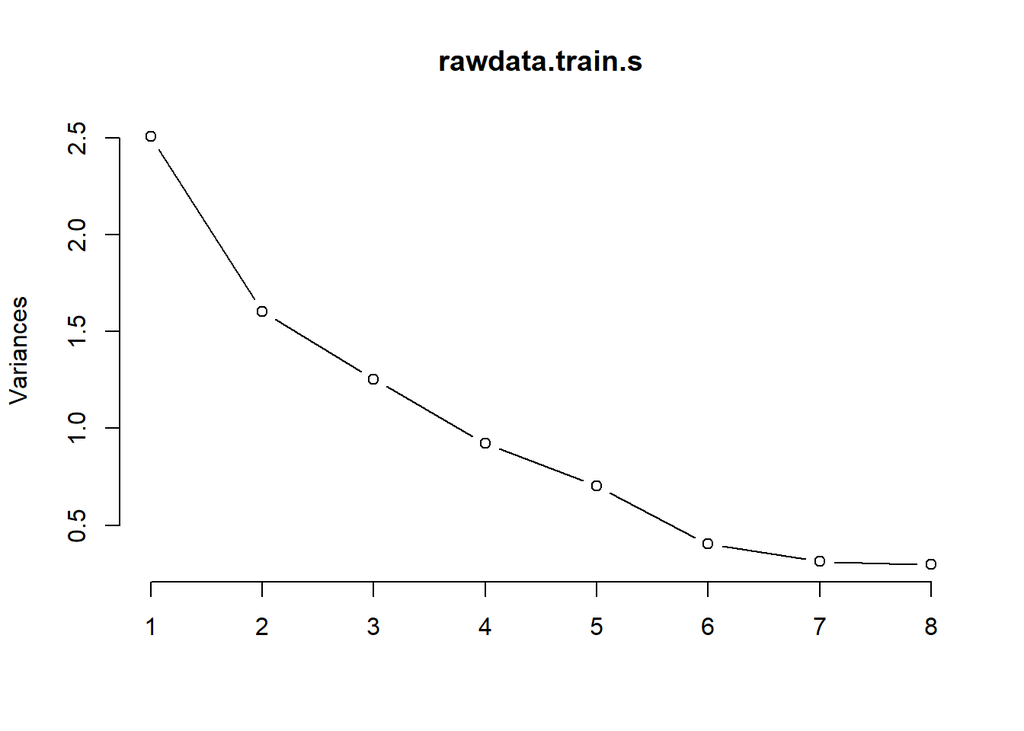

```r
screeplot(rawdata.train.s,type="l") # keep PC1, PC2, PC3, PC4, PC5,PC6
```

```r
train.data<-data.frame(diabetes=rawdata[train,]$diabetes,rawdata.train.s$x)
head(train.data,5)
```

```
##     diabetes         PC1        PC2        PC3        PC4        PC5
## 217        1  0.02241069 -0.6023917 -0.6846347  0.1053258 -1.1974575
## 298        0  0.11866566 -0.7747926  0.3117224 -0.3971402  1.2975169
## 442        0  1.76180145 -0.3276163 -0.7247281  0.2366394  0.1409261
## 689        0  0.60706563 -0.2533225  1.0824853  0.6924393  1.0016688
## 162        0 -1.02300328  0.9010808 -1.7232825 -0.5308006 -0.9895110
##               PC6         PC7          PC8
## 217  0.0009046691  0.08691877 -0.758028417
## 298  0.0651699685 -0.74470963 -0.239615857
## 442  0.3464797276  0.21257314 -0.004169761
## 689 -0.5006735459 -0.65546077 -0.604065514
## 162  0.2025101247 -0.28635196  0.225361765
```

```r
test.data<-predict(rawdata.train.s,newdata=rawdata[-train,1:8])
test.data<-data.frame(diabetes=rawdata[-train,]$diabetes,test.data)
```

Based on the new predictors, run a random forest tree.

```r
library(randomForest)
library(ISLR)
set.seed(1)
rf.model.pca <- randomForest(as.factor(train.data$diabetes) ~ .,
                         data=train.data,
                         xtest = test.data[-diabetes], ytest =as.factor(test.data$diabetes),
                         ntree=B,
                         mtry=sqrt(8),
                         importance=T)
rf.model.pca
```

```
##
## Call:
##  randomForest(formula = as.factor(train.data$diabetes) ~ ., data = train.data,      xtest = test.data[-diabetes], ytest = as.factor(test.data$diabetes),      ntree = B, mtry = sqrt(8), importance = T)
##                Type of random forest: classification
##                      Number of trees: 5000
## No. of variables tried at each split: 3
##
##         OOB estimate of  error rate: 24.84%
## Confusion matrix:
##     0  1 class.error
## 0 181 33   0.1542056
## 1  45 55   0.4500000
##                 Test set error rate: 21.79%
## Confusion matrix:
##    0  1 class.error
## 0 45  3   0.0625000
## 1 14 16   0.4666667
```

## It’s hard to inteprete variable importance with PCA

## Variable importance

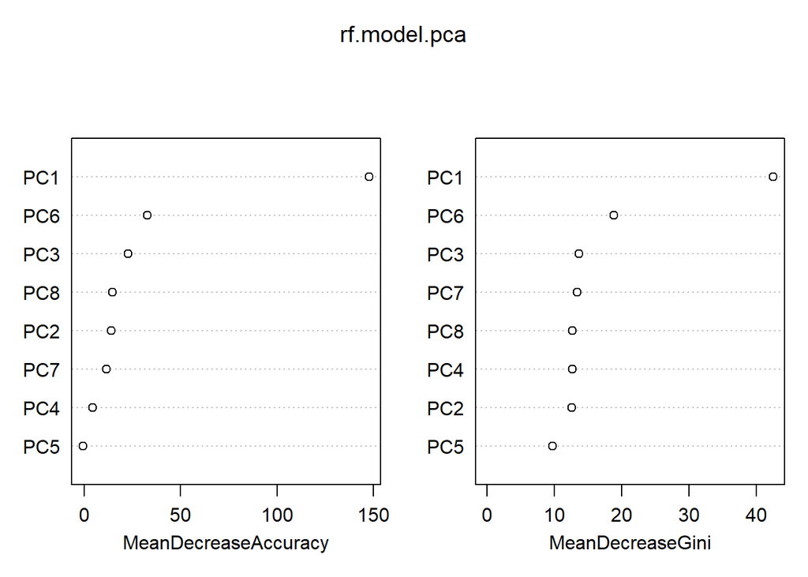

```r
varImpPlot(rf.model.pca)
```

Refer from : https://rpubs.com/njvijay/27823

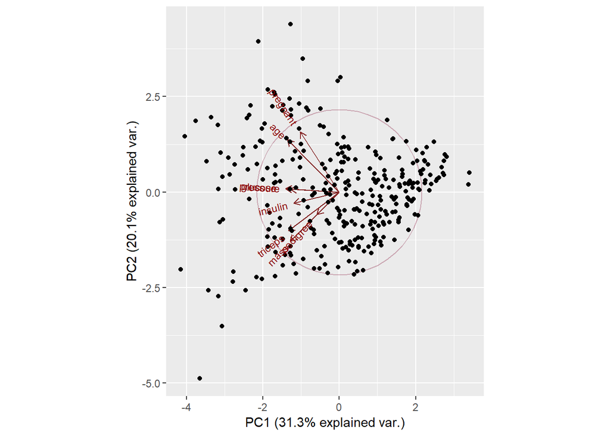

```r
library(ggplot2)
library(plyr)
library(scales)
library(grid)
library(devtools)
library(ggbiplot)
g <- ggbiplot(rawdata.train.s, obs.scale = 1, var.scale = 1,
              ellipse = TRUE,
              circle = TRUE)
g <- g + scale_color_discrete(name = '')
g <- g + theme(legend.direction = 'horizontal',
               legend.position = 'top')
print(g)
```

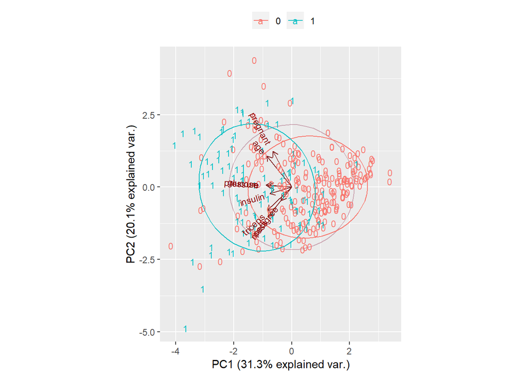

```r
# install_github("vqv/ggbiplot")
library(ggplot2)
library(plyr)
library(scales)
library(grid)
library(devtools)
library(ggbiplot)
g <- ggbiplot(rawdata.train.s,scale = 0, var.scale = 0, labels=as.factor(train.data$diabetes),groups = as.factor(train.data$diabetes),ellipse = TRUE, circle = TRUE)
g <- g + scale_color_discrete(name = '')
g <- g + theme(legend.direction = 'horizontal',
               legend.position = 'top')
print(g)
```

```r
rawdata.train.s$rotation[,1:2]
```

```
##                 PC1         PC2
## pregnant -0.2991264  0.57414017
## glucose  -0.4107050  0.03501905
## pressure -0.3746080  0.02988471
## triceps  -0.3899148 -0.37196011
## insulin  -0.3497642 -0.10412173
## mass     -0.3754345 -0.47178474
## pedigree -0.1707595 -0.21577303
## age      -0.3962767  0.49990913
```

The second loading vector places most of it weight on age and preganant. Hence, this component roughly corresponds to the individual natural feature.

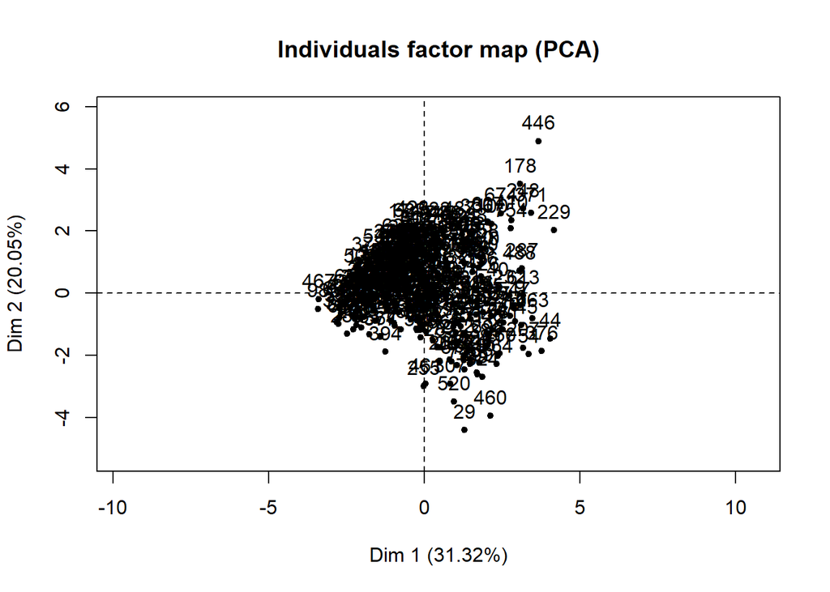

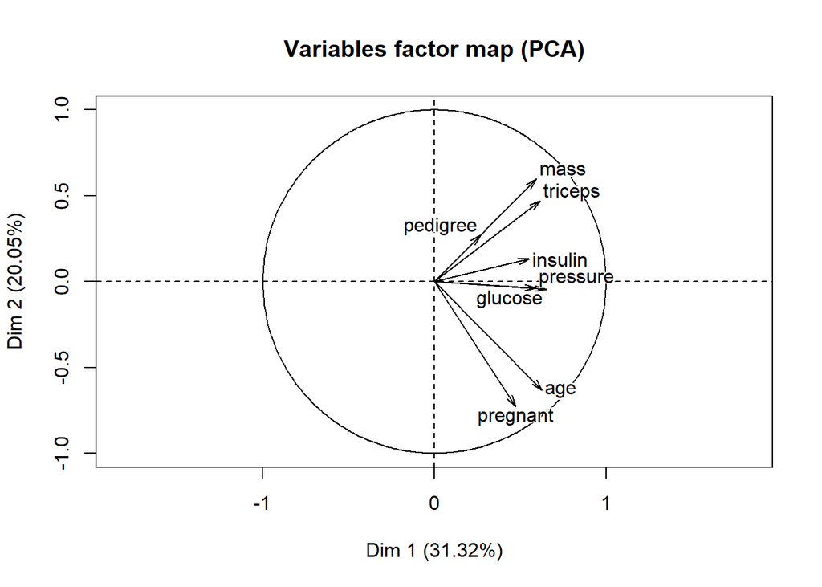

```
##              Dim.1       Dim.2     Dim.3       Dim.4      Dim.5
## pregnant  8.947657 32.96369327  3.852317  1.21887305  5.8735237
## glucose  16.867858  0.12263340 27.304328  2.18213337  1.2503854
## pressure 14.033118  0.08930958 11.596819  1.82064724 66.1197795
## triceps  15.203352 13.83543227  9.664819  0.05135086 20.4522021
## insulin  12.233498  1.08413347 36.727703  3.67089794  0.3602508
## mass     14.095110 22.25808387  7.822311  1.82011335  1.1312241
## pedigree  2.915880  4.65580010  2.078303 87.97332611  2.0855532
## age      15.703526 24.99091404  0.953400  1.26265807  2.7270812
```

```r
library(FactoMineR)
PCA(rawdata[train,c(1:8)])$var$contrib
```